# MCCS G-Formula Simulation Results with increasing Var(eps)

Brian Richardson

10/29/2024

```r
rm(list = ls())
library(dplyr)
library(tidyverse)
library(ggplot2)
library(ggh4x)
library(kableExtra)
library(devtools)
load_all()
```

The goal of this program is to evaluate the Monte Carlo corrected score G-formula (MCCS G-FMLA) estimator in the presence of confounding and measurement error, where the measurement error variance increases.

## Setup

This data generating process leads to a mean potential outcome at $a$ of $\textrm{E}\{Y(a)\} = 0.4\textrm{logit}^{-1}(-2+0.7a) + 0.4\textrm{logit}^{-1}(-2.6+0.3a) + 0.1\textrm{logit}^{-1}(-1.6+0.5a) + 0.1\textrm{logit}^{-1}(-2.2+0.1a)$.

The estimand of interest in these simulations is the dose response curve $\{\textrm{E}[Y(a)] : a \in \mathcal{A}\}$.

## Methods

In these simulations, we compare three methods:

1. Oracle G-Formula
2. Naive G-Formula
3. Corrected G-Formula

The oracle method uses the true exposure values $A$, which are not observed in practice. The naive method treats $A^*$ as $A$, assuming there is no measurement error. The corrected method uses the Monte-Carlo corrected score versions of the estimating functions, which account for measurement error.

In these simulations, we vary the reliability of the exposure, defined as $\textrm{Var}(A) / \textrm{Var}(A^*)$ between $0.5$ and $1$.

## Results

```r
# load simulation results from each of 10 clusters
sim.out.list <- lapply(
  X = 0:9,
  FUN = function(clust) {
    cbind(clust,
          read.csv(paste0("sim_data/gfmla_bige_data/sd",
                          clust, ".csv")))
  })


# combine simulation results into 1 data frame
sim.out <- bind_rows(sim.out.list)

# true estimands
g <- c(-2, 0.7, -0.6, 0.4, -0.4, -0.2)          # outcome model parameters
a <- 3                                      # exposure value of interest
EYa.true <- 0.4 * inv.logit(-2 + 0.7 * a) +     # true dose response curve at a
  0.4 * inv.logit(-2.6 + 0.3 * a) +
  0.1 * inv.logit(-1.6 + 0.5 * a) +
  0.1 * inv.logit(-2.2 + 0.1 * a)

# number of sims per setting
n.rep <- nrow(sim.out) / n_distinct(dplyr::select(sim.out, n, B, vare))

# make long data frame
sim.out.long <- sim.out %>%
  pivot_longer(cols = starts_with("est") |
                      starts_with("ste") |
                      starts_with("bcs"),
               names_to = "method.aa",
               values_to = "val") %>%
    mutate(method = factor(substr(method.aa, 5, 6),
                           levels = c("OG", "NG", "CG"),
                           labels = c("Oracle G-Formula",
                                      "Naive G-Formula",
                                      "G-Formula CS")),
           aa = factor(substr(method.aa, 8, 8)),
           a = factor(a[aa]),
           name = factor(substr(method.aa, 1, 3)),
           EYa.true = EYa.true[aa],
           reliab = 0.6625 / (0.6625 + vare)) %>%
  dplyr::select(-method.aa) %>%
  group_by(clust, n, B, reliab, method, aa, a, name) %>%
  mutate(id = row_number()) %>%
  pivot_wider(names_from = name,
              values_from = val,
              id_cols = c(clust, n, B, reliab, method, aa, a, EYa.true, id)) %>%
  mutate(ci.lower = est - qnorm(0.975) * ste,
         ci.upper = est + qnorm(0.975) * ste,
         ci.cov = EYa.true >= ci.lower & EYa.true <= ci.upper,
         bcci.lower = est - qnorm(0.975) * bcs,
         bcci.upper = est + qnorm(0.975) * bcs,
         bcci.cov = EYa.true >= bcci.lower & EYa.true <= bcci.upper)
```

We first check for simulations with errors.

```r
# summarize proportion of missing data by setting
ftc.dat <- sim.out.long %>%
  filter(aa == 1) %>%
  group_by(method, n, B, reliab) %>%
  summarise(prop.error = mean(is.na(est)))
ftc.dat %>%
  filter(prop.error > 0) %>%
  ungroup()
```

```
## # A tibble: 7 × 5
##   method           n     B reliab prop.error
##   <fct>        <int> <int>  <dbl>      <dbl>
## 1 G-Formula CS   800    80  0.5        0.005
## 2 G-Formula CS   800    80  0.556      0.006
## 3 G-Formula CS   800    80  0.611      0.002
## 4 G-Formula CS   800    80  0.667      0.002
## 5 G-Formula CS   800    80  0.722      0.001
## 6 G-Formula CS   800    80  0.778      0.001
## 7 G-Formula CS  8000    80  0.5        0.003
```

```r
# extract simulation parameters
n <- unique(sim.out$n)

# make labels for plots
method.labs <- c("Oracle G-Formula",
                 "Naive G-Formula",
                 "G-Formula CS")

names(method.labs) <- c("OG", "NG", "CG")

n.labs <- paste0("n = ", n)
names(n.labs) <- n

a.labs <- paste0("a = ", a)
names(a.labs) <- a

reliab.lab = unique(round(sim.out.long$reliab, 2))
reliab.lab[seq(2, n_distinct(reliab.lab), 2)] <- ""

# colorblind friendly pallette
pal_light <- c('#EE6677', '#228833', '#4477AA', '#CCBB44', '#66CCEE', '#AA3377', '#BBBBBB')
pal_dark <- c('#991122', '#114419', '#223b55', '#6b611d', '#117799', '#55193b', '#5d5d5d')
```

```r
# create plots
make.plot <- function(title = F) {

  plot <- sim.out.long %>%
    filter(method != "Oracle G-Formula") %>%
    mutate(reliab = factor(reliab)) %>%
    ggplot(aes(x = reliab, y = est, group = reliab)) +
    geom_boxplot(width = 0.7, outlier.size = 0.5) +
    geom_hline(aes(yintercept = EYa.true),
               linetype = "dashed",
               color = "orange") +
    facet_grid(n ~ method,
               scales = "free",
               labeller = labeller(n = n.labs)) +
    labs(y = "Parameter Estimate",
         x = "Exposure Reliability",
         fill = "Method",
         color = "Method") +
    theme_bw() +
    theme(legend.position = "bottom") +
    scale_x_discrete(labels = reliab.lab)


  if (title) {
    plot <- plot +
      ggtitle(paste0("Empirical Distribution of Parameter Estimates"),
              subtitle = paste0(n.rep, " simulations per setting"))

  }
  return(plot)
}
```

```r
# create plots
make.plot.2 <- function(title = F) {

  plot <- sim.out.long %>%
    filter(method != "Oracle G-Formula") %>%
    pivot_longer(cols = ends_with(".cov"),
                 names_to = "ci.type",
                 values_to = "ci.cov") %>%
    mutate(ci.type = ifelse(ci.type == "bcci.cov", "Bias-Corrected", "Uncorrected")) %>%
    group_by(reliab, n, method, ci.type) %>%
    summarise(cov = mean(ci.cov, na.rm = T)) %>%
    ggplot(aes(x = reliab,
               linetype = ci.type,
               y = cov)) +
    geom_line() +
    geom_hline(yintercept = 0.95,
               linetype = "dashed",
               color = "orange") +
    facet_grid(n ~ method,
               scales = "free",
               labeller = labeller(n = n.labs)) +
    labs(y = "Coverage Probability",
         x = "Exposure Reliability",
         linetype = "CI Type") +
    theme_bw() +
    theme(legend.position = "bottom")

  if (title) {
    plot <- plot +
      ggtitle(paste0("Empirical Coverage Probabilities of 95% Confidence Intervals"),
              subtitle = paste0(n.rep, " simulations per setting"))

  }
  return(plot)
}
```

### Plots of Simulation Results

Below are boxplots of the empirical distributions of estimators for $\textrm{E}\{Y(a)\}$ at $a=3$, and plots of coverage probabilities of confidence intervals.

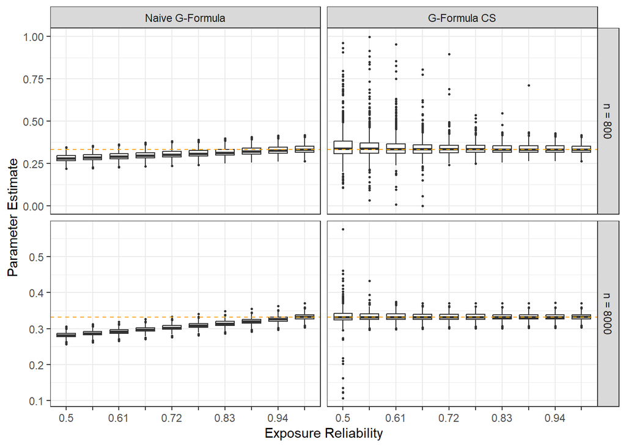

```r
make.plot()
```

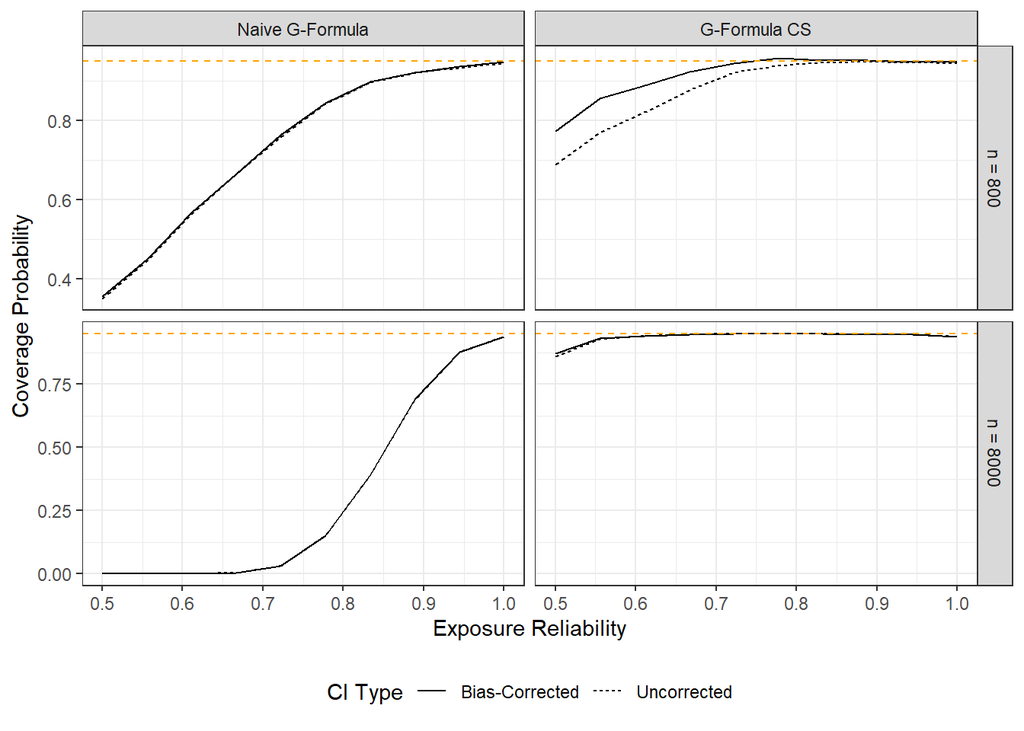

```r
# save plot
ggsave("sim_figures/gfmla_sim_bige_plot_1.png",
       width = 6,
       height = 4,
       dpi = 300)
make.plot.2()
```

```r
# save plot
ggsave("sim_figures/gfmla_sim_bige_plot_2.png",
       width = 6,
       height = 4,
       dpi = 300)
```

### Tables of Simulation Results

Below is a table for the primary estimand of interest ($a=3$) and for $n \in \{800, 8000\}$. It includes empirical bias, empirical standard error (ESE), average estimated standard error (ASE), and empirical coverage probability of the 95% CI.

```r
tbl <- sim.out.long %>%
  group_by(n, method, reliab) %>%
  summarise(bias = 100 * mean(est - EYa.true, na.rm = T),
            emp.se = 100 * sd(est, na.rm = T),
            est.se = 100 * mean(ste, na.rm = T),
            ci.cov = 100 * mean(ci.cov, na.rm = T),
            bcest.se = 100 * mean(bcs, na.rm = T),
            bcci.cov = 100 * mean(bcci.cov, na.rm = T)) %>%
  left_join(ftc.dat) %>%
  dplyr::select(n, method, reliab, bias, emp.se,
                est.se, ci.cov, bcest.se, bcci.cov)
kbl <- tbl %>%
  kable(format = "latex",
        digits = c(0, 0, 2, 1, 1, 1, 1, 1, 1, 1),
        align = c(rep("c", 3),
                  rep("r", 7)),
        booktabs = TRUE,
        linesep = c("", "", "\\addlinespace"),
        escape = FALSE,
        col.names = c("n", "Method", "Exposure Reliability",
                      "Bias", "ESE",
                      "ASE", "Cov",
                      "ASE", "Cov")) %>%
  add_header_above(c(" " = 4,
                     "UC" = 2,
                     "BC" = 2)) %>%
  kable_styling("striped") %>%
  row_spec(row = 0, bold = TRUE)

tbl
```

```
## # A tibble: 60 × 9
## # Groups:   n, method [6]
##        n method           reliab  bias emp.se est.se ci.cov bcest.se bcci.cov
##    <int> <fct>             <dbl> <dbl>  <dbl>  <dbl>  <dbl>    <dbl>    <dbl>
##  1   800 Oracle G-Formula  0.5   0.102   2.70   2.76   94.5     2.80     94.9
##  2   800 Oracle G-Formula  0.556 0.102   2.70   2.76   94.5     2.80     94.9
##  3   800 Oracle G-Formula  0.611 0.102   2.70   2.76   94.5     2.80     94.9
##  4   800 Oracle G-Formula  0.667 0.102   2.70   2.76   94.5     2.80     94.9
##  5   800 Oracle G-Formula  0.722 0.102   2.70   2.76   94.5     2.80     94.9
##  6   800 Oracle G-Formula  0.778 0.102   2.70   2.76   94.5     2.80     94.9
##  7   800 Oracle G-Formula  0.833 0.102   2.70   2.76   94.5     2.80     94.9
##  8   800 Oracle G-Formula  0.889 0.102   2.70   2.76   94.5     2.80     94.9
##  9   800 Oracle G-Formula  0.944 0.102   2.70   2.76   94.5     2.80     94.9
## 10   800 Oracle G-Formula  1     0.102   2.70   2.76   94.5     2.80     94.9
## # ℹ 50 more rows
```